# Vehicular Accident Data from Montgomery County Police

## Overview

Vehicular accidents happen all over the world on a daily basis and learning to travel smart is always critical. For many people, travelling by car is the preferred means of transportion but the question of how safe is it always lingers. This tutorial will cover an analysis of traffic accident data collected by Montgomery County Police in the state of Maryland.

The reason for covering this data is in part to looking at a current goal by the department called Vision Zero. Vision Zero is a multinational road safety project that envisions a world where we no longer have traffic accidents or deaths. It originally started in Sweden in 1997 and has since been adopted by many countries around the world. Montgomery County adopted this goal and has the overarching goal to eliminate fatalities and severe injuries by 2030. Their short term goal for this project is to reduce collisions by 35% by November 2019.

## Required Tools

I am using the Jupyter Notebook since it already has Python included and I will be using the following libraries as well:

- Pandas
- Numpy
- Matplotlib
- scikit-learn
- statsmodels OLS

The dataset can be collected here: https://data.montgomerycountymd.gov/Public-Safety/Crash-Reporting-Incidents-Data/bhju-22kf

# Data Preparation

First thing needed is the dataset from the link above. The data from that page is refreshed on a daily basis, the most recent refresh that I have used is on December 12, 2018. I downloaded the data in a CSV format and loaded it into Jupyter Notebook to analyze. Pandas helps a lot with creating the initial dataframes to visualize and manipulate my data.

If you are unfamiliar with Pandas, the complete documentation can be found at: https://pandas.pydata.org/pandas-docs/stable/

If you wish to obtain just an overview of functions used for data wrangling, that can be found here: https://pandas.pydata.org/Pandas_Cheat_Sheet.pdf

```python
import pandas as pd
import numpy as np
import matplotlib.pyplot as plt
from sklearn import linear_model
from statsmodels.formula.api import ols
```

```python
data = pd.read_csv("Crash_Reporting_-_Incidents_Data.csv", dtype=object)
data.head()
```

|  | Report Number | Local Case Number | Agency Name | ACRS Report Type | Crash Date/Time | Route Type | Road Name | Cross-Street Type | Cross-Street Name | Off-Road Description | ... | Second Harmful Event | Fixed Oject Struck | Junction | Intersection Type | Road Alignment | Road Condition | Road Division | Latitude | Longitude | Location |
| --- | --- | --- | --- | --- | --- | --- | --- | --- | --- | --- | --- | --- | --- | --- | --- | --- | --- | --- | --- | --- | --- |
| 0 | MCP26890028 | 16046213 | Montgomery County Police | Property Damage Crash | 09/09/2016 01:53:00 PM | County | E JEFFERSON ST | Unknown | CALIFORNIA CIR | NaN | ... | NaN | NaN | NON INTERSECTION | NaN | STRAIGHT | NO DEFECTS | TWO-WAY, NOT DIVIDED WITH A CONTINUOUS LEFT TURN | 39.05685333 | -77.126215 | (39.05685333, -77.126215) |
| 1 | MCP11520005 | 15000008 | Montgomery County Police | Property Damage Crash | 01/01/2015 12:30:00 AM | Maryland (State) | ROCKVILLE PIKE | County | GROSVENOR LA | NaN | ... | NaN | NaN | INTERSECTION RELATED | FOUR-WAY INTERSECTION | STRAIGHT | NO DEFECTS | TWO-WAY, DIVIDED, POSITIVE MEDIAN BARRIER | 39.02200107 | -77.10267305 | (39.02200107, -77.10267305) |
| 2 | MCP2916001N | 170521681 | Montgomery County Police | Property Damage Crash | 07/28/2017 02:00:00 PM | NaN | NaN | NaN | NaN | 14620 PALMER HOUSE WAY | ... | NaN | NaN | NaN | NaN | NaN | NaN | NaN | 39.05121333 | -76.98839667 | (39.05121333, -76.98839667) |
| 3 | DD56040016 | 15051858 | ROCKVILLE | Property Damage Crash | 10/12/2015 11:59:00 PM | Municipality | EDMONSTON DR | Municipality | CRAWFORD DR | NaN | ... | NaN | NaN | NON INTERSECTION | NaN | CURVE LEFT | NO DEFECTS | TWO-WAY, DIVIDED, UNPROTECTED PAINTED MIN 4 FEET | 39.07749833 | -77.13099333 | (39.07749833, -77.13099333) |
| 4 | MCP1502000L | 15058824 | MONTGOMERY | Injury Crash | 11/18/2015 05:54:00 AM | County | SNOUFFERS SCHOOL RD | County | GOSHEN RD | NaN | ... | NaN | NaN | INTERSECTION | T-INTERSECTION | STRAIGHT | NO DEFECTS | TWO-WAY, NOT DIVIDED | 39.161005 | -77.163395 | (39.161005, -77.163395) |

5 rows × 31 columns

## Data Overview and Tidying

The dataset contains data collected by various agencies and reports various information such as the type of crash, date and time, location, who/what was hit, etc. Some of this information is not needed for analysis and is thus removed by the following lines of code.

```python
#drop off columns not needed
data = data.drop('Report Number', 1)
data = data.drop('Local Case Number', 1)
data = data.drop('Route Type', 1)
data = data.drop('Second Harmful Event', 1)
data = data.drop('Fixed Oject Struck', 1)
data = data.drop('Road Condition', 1)
data = data.drop('Road Division', 1)
data = data.drop('Location', 1)

data.head()
```

|  | Agency Name | ACRS Report Type | Crash Date/Time | Road Name | Cross-Street Type | Cross-Street Name | Off-Road Description | Municipality | Related Non-Motorist | At Fault | ... | Light | Traffic Control | Driver Substance Abuse | Non-Motorist Substance Abuse | First Harmful Event | Junction | Intersection Type | Road Alignment | Latitude | Longitude |
| --- | --- | --- | --- | --- | --- | --- | --- | --- | --- | --- | --- | --- | --- | --- | --- | --- | --- | --- | --- | --- | --- |
| 0 | Montgomery County Police | Property Damage Crash | 09/09/2016 01:53:00 PM | E JEFFERSON ST | Unknown | CALIFORNIA CIR | NaN | NaN | NaN | DRIVER | ... | DAYLIGHT | NO CONTROLS | NONE DETECTED | NaN | OTHER VEHICLE | NON INTERSECTION | NaN | STRAIGHT | 39.05685333 | -77.126215 |
| 1 | Montgomery County Police | Property Damage Crash | 01/01/2015 12:30:00 AM | ROCKVILLE PIKE | County | GROSVENOR LA | NaN | NaN | NaN | DRIVER | ... | DARK LIGHTS ON | TRAFFIC SIGNAL | ALCOHOL CONTRIBUTED, N/A | NaN | OTHER VEHICLE | INTERSECTION RELATED | FOUR-WAY INTERSECTION | STRAIGHT | 39.02200107 | -77.10267305 |
| 2 | Montgomery County Police | Property Damage Crash | 07/28/2017 02:00:00 PM | NaN | NaN | NaN | 14620 PALMER HOUSE WAY | NaN | NaN | DRIVER | ... | DAYLIGHT | NO CONTROLS | NONE DETECTED | NaN | OTHER VEHICLE | NaN | NaN | NaN | 39.05121333 | -76.98839667 |
| 3 | ROCKVILLE | Property Damage Crash | 10/12/2015 11:59:00 PM | EDMONSTON DR | Municipality | CRAWFORD DR | NaN | ROCKVILLE | NaN | DRIVER | ... | DARK LIGHTS ON | NO CONTROLS | NONE DETECTED | NaN | PARKED VEHICLE | NON INTERSECTION | NaN | CURVE LEFT | 39.07749833 | -77.13099333 |
| 4 | MONTGOMERY | Injury Crash | 11/18/2015 05:54:00 AM | SNOUFFERS SCHOOL RD | County | GOSHEN RD | NaN | NaN | NaN | DRIVER | ... | DARK NO LIGHTS | STOP SIGN | NONE DETECTED | NaN | OTHER VEHICLE | INTERSECTION | T-INTERSECTION | STRAIGHT | 39.161005 | -77.163395 |

5 rows × 23 columns

I'm also going to be removing any data that isn't collected by MCP directly. In addition, I am renaming cases of MONTGOMERY to Montgomery County Police just for readability.

```python
data['Agency Name'] = data['Agency Name'].replace('MONTGOMERY', 'Montgomery County Police')

data = data[data['Agency Name'] == 'Montgomery County Police']

data.head()
```

|  | Agency Name | ACRS Report Type | Crash Date/Time | Road Name | Cross-Street Type | Cross-Street Name | Off-Road Description | Municipality | Related Non-Motorist | At Fault | ... | Light | Traffic Control | Driver Substance Abuse | Non-Motorist Substance Abuse | First Harmful Event | Junction | Intersection Type | Road Alignment | Latitude | Longitude |
| --- | --- | --- | --- | --- | --- | --- | --- | --- | --- | --- | --- | --- | --- | --- | --- | --- | --- | --- | --- | --- | --- |
| 0 | Montgomery County Police | Property Damage Crash | 09/09/2016 01:53:00 PM | E JEFFERSON ST | Unknown | CALIFORNIA CIR | NaN | NaN | NaN | DRIVER | ... | DAYLIGHT | NO CONTROLS | NONE DETECTED | NaN | OTHER VEHICLE | NON INTERSECTION | NaN | STRAIGHT | 39.05685333 | -77.126215 |
| 1 | Montgomery County Police | Property Damage Crash | 01/01/2015 12:30:00 AM | ROCKVILLE PIKE | County | GROSVENOR LA | NaN | NaN | NaN | DRIVER | ... | DARK LIGHTS ON | TRAFFIC SIGNAL | ALCOHOL CONTRIBUTED, N/A | NaN | OTHER VEHICLE | INTERSECTION RELATED | FOUR-WAY INTERSECTION | STRAIGHT | 39.02200107 | -77.10267305 |
| 2 | Montgomery County Police | Property Damage Crash | 07/28/2017 02:00:00 PM | NaN | NaN | NaN | 14620 PALMER HOUSE WAY | NaN | NaN | DRIVER | ... | DAYLIGHT | NO CONTROLS | NONE DETECTED | NaN | OTHER VEHICLE | NaN | NaN | NaN | 39.05121333 | -76.98839667 |
| 4 | Montgomery County Police | Injury Crash | 11/18/2015 05:54:00 AM | SNOUFFERS SCHOOL RD | County | GOSHEN RD | NaN | NaN | NaN | DRIVER | ... | DARK NO LIGHTS | STOP SIGN | NONE DETECTED | NaN | OTHER VEHICLE | INTERSECTION | T-INTERSECTION | STRAIGHT | 39.161005 | -77.163395 |
| 6 | Montgomery County Police | Property Damage Crash | 07/20/2017 11:10:00 AM | SLIGO AVE | County | FENTON ST | NaN | NaN | NaN | DRIVER | ... | DAYLIGHT | NaN | NONE DETECTED | NaN | OTHER VEHICLE | COMMERCIAL DRIVEWAY | NaN | STRAIGHT | 38.99012167 | -77.02237667 |

5 rows × 23 columns

# Data Visualization

Now I want to analyze the dataset that I have modified. In addition, I want to visualize various aspects of this set including crimes over years and substance abuse (if it had any weight to an accident)

## Crashes by Year

First up is crashes per year. I want to know how many crashes we have in a single year over the span of my dataset. This code creates a table that will show how many crashes were recorded by MCP in each year from 2015-2017 and all the current recorded accidents in 2018 as of the latest refresh of the dataset.

```python
data2015 = data[data['Crash Date/Time'].str.contains('2015')]
data2016 = data[data['Crash Date/Time'].str.contains('2016')]
data2017 = data[data['Crash Date/Time'].str.contains('2017')]
data2018 = data[data['Crash Date/Time'].str.contains('2018')]

counts = {'Year': [2015, 2016, 2017, 2018], 'Accident Count': [data2015.shape[0], data2016.shape[0], data2017.shape[0], data2018.shape[0]]}
countsDF = pd.DataFrame(data = counts)
countsDF
```

|  | Year | Accident Count |
| --- | --- | --- |
| 0 | 2015 | 10003 |
| 1 | 2016 | 10543 |
| 2 | 2017 | 10464 |
| 3 | 2018 | 9682 |

This next graph simply plots the data as a line plot. For this section, I used Matplotlib (documentation and learning resources can be found at https://matplotlib.org/) and plotted Year vs. Accident Count

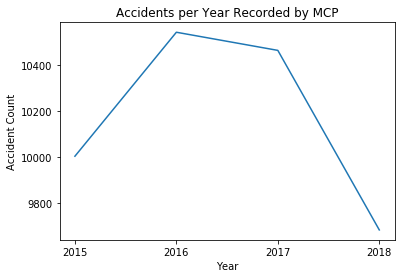

```python
xi = [2015, 2016, 2017, 2018]
plt.plot(countsDF['Year'], countsDF['Accident Count'])
plt.xlabel('Year')
plt.ylabel('Accident Count')
plt.xticks(xi, countsDF['Year'])
plt.title('Accidents per Year Recorded by MCP')
plt.show()
```

I'm removing the timestamp on these daates because it isn't entirely useful for what I want. I want to map crashes through the year and having the timestamp would make this graph far too cluttered.

The next step is to create a few plots to see how many accidents happened on each day of the year for years 2015 until 12/12/2018.

```python
data['Crash Date/Time'] = data['Crash Date/Time'].str.slice(start=0, stop=10)

data.head()
```

|  | Agency Name | ACRS Report Type | Crash Date/Time | Road Name | Cross-Street Type | Cross-Street Name | Off-Road Description | Municipality | Related Non-Motorist | At Fault | ... | Light | Traffic Control | Driver Substance Abuse | Non-Motorist Substance Abuse | First Harmful Event | Junction | Intersection Type | Road Alignment | Latitude | Longitude |
| --- | --- | --- | --- | --- | --- | --- | --- | --- | --- | --- | --- | --- | --- | --- | --- | --- | --- | --- | --- | --- | --- |
| 0 | Montgomery County Police | Property Damage Crash | 09/09/2016 | E JEFFERSON ST | Unknown | CALIFORNIA CIR | NaN | NaN | NaN | DRIVER | ... | DAYLIGHT | NO CONTROLS | NONE DETECTED | NaN | OTHER VEHICLE | NON INTERSECTION | NaN | STRAIGHT | 39.05685333 | -77.126215 |
| 1 | Montgomery County Police | Property Damage Crash | 01/01/2015 | ROCKVILLE PIKE | County | GROSVENOR LA | NaN | NaN | NaN | DRIVER | ... | DARK LIGHTS ON | TRAFFIC SIGNAL | ALCOHOL CONTRIBUTED, N/A | NaN | OTHER VEHICLE | INTERSECTION RELATED | FOUR-WAY INTERSECTION | STRAIGHT | 39.02200107 | -77.10267305 |
| 2 | Montgomery County Police | Property Damage Crash | 07/28/2017 | NaN | NaN | NaN | 14620 PALMER HOUSE WAY | NaN | NaN | DRIVER | ... | DAYLIGHT | NO CONTROLS | NONE DETECTED | NaN | OTHER VEHICLE | NaN | NaN | NaN | 39.05121333 | -76.98839667 |
| 4 | Montgomery County Police | Injury Crash | 11/18/2015 | SNOUFFERS SCHOOL RD | County | GOSHEN RD | NaN | NaN | NaN | DRIVER | ... | DARK NO LIGHTS | STOP SIGN | NONE DETECTED | NaN | OTHER VEHICLE | INTERSECTION | T-INTERSECTION | STRAIGHT | 39.161005 | -77.163395 |
| 6 | Montgomery County Police | Property Damage Crash | 07/20/2017 | SLIGO AVE | County | FENTON ST | NaN | NaN | NaN | DRIVER | ... | DAYLIGHT | NaN | NONE DETECTED | NaN | OTHER VEHICLE | COMMERCIAL DRIVEWAY | NaN | STRAIGHT | 38.99012167 | -77.02237667 |

5 rows × 23 columns

```python
dataByDate = data.copy().groupby(data['Crash Date/Time'], as_index=True, group_keys=True).count()
dateCount = dataByDate[['Agency Name']].reset_index()
dateCount = dateCount.rename(index=str, columns={'Agency Name' : 'Count'})
dateCount.head()
```

|  | Crash Date/Time | Count |
| --- | --- | --- |
| 0 | 01/01/2015 | 21 |
| 1 | 01/01/2016 | 12 |
| 2 | 01/01/2017 | 28 |
| 3 | 01/01/2018 | 20 |
| 4 | 01/02/2015 | 18 |

```python
dateCount = dateCount.astype(str)

crashes2015 = dateCount[dateCount['Crash Date/Time'].str.contains('2015')]
crashes2016 = dateCount[dateCount['Crash Date/Time'].str.contains('2016')]
crashes2017 = dateCount[dateCount['Crash Date/Time'].str.contains('2017')]
crashes2018 = dateCount[dateCount['Crash Date/Time'].str.contains('2018')]
```

```
 <a list of 6 Text yticklabel objects>)
```

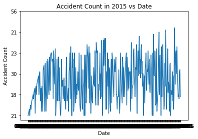

```python
yi = [0, 10, 20, 30, 40, 50]
plt.plot(crashes2015['Crash Date/Time'], crashes2015['Count'])
plt.ylabel('Accident Count')
plt.xlabel('Date')
plt.title('Accident Count in 2015 vs Date')
plt.yticks(yi, crashes2015['Count'])
```

```
 <a list of 6 Text yticklabel objects>)
```

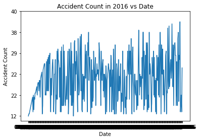

```python
yi = [0, 10, 20, 30, 40, 50]
plt.plot(crashes2016['Crash Date/Time'], crashes2016['Count'])
plt.ylabel('Accident Count')
plt.xlabel('Date')
plt.title('Accident Count in 2016 vs Date')
plt.yticks(yi, crashes2016['Count'])
```

```
 <a list of 6 Text yticklabel objects>)
```

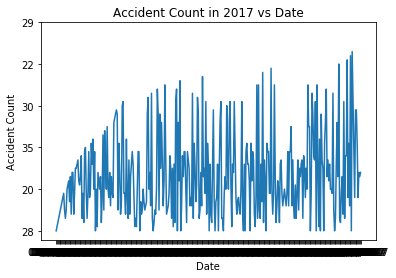

```python
yi = [0, 10, 20, 30, 40, 50]
plt.plot(crashes2017['Crash Date/Time'], crashes2017['Count'])
plt.ylabel('Accident Count')
plt.xlabel('Date')
plt.title('Accident Count in 2017 vs Date')
plt.yticks(yi, crashes2017['Count'])
```

```
 <a list of 6 Text yticklabel objects>)
```

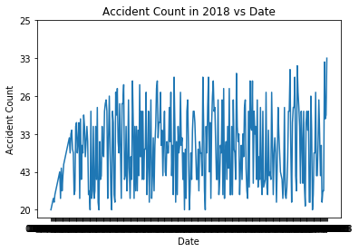

```python
yi = [0, 10, 20, 30, 40, 50]
plt.plot(crashes2018['Crash Date/Time'], crashes2018['Count'])
plt.ylabel('Accident Count')
plt.xlabel('Date')
plt.title('Accident Count in 2018 vs Date')
plt.yticks(yi, crashes2018['Count'])
```

We can see from these various graphs that in each year, there is a huge variance in accident count mapped to date. The year generally starts off with a low accident count but ramps up quickly. In each year, there are consistent spikes in accident counts near November and December, presumably around the time people go on vacation and travel.

The next step is to see how many accidents occur each year due to substance abuse if it was present during the accident. I have removed the date and month values from the date field so that I can look purely at accidents on a yearly basis. I can then use the groupby function from Pandas to count Substance Abuse (if recorded/available) vs Year.

```python
data['Crash Date/Time'] = data['Crash Date/Time'].str.slice(start=6, stop=10)
```

```python
dataByCrashReason = data.copy().groupby(['Driver Substance Abuse', 'Crash Date/Time'], as_index=True, group_keys=True).count()
dataByCrashReason = dataByCrashReason[['Agency Name']].reset_index()
dataByCrashReason = dataByCrashReason.rename(index=str, columns={'Agency Name' : 'Count'})
```

```python
dataByCrashReason
```

|  | Driver Substance Abuse | Crash Date/Time | Count |
| --- | --- | --- | --- |
| 0 | ALCOHOL CONTRIBUTED | 2015 | 90 |
| 1 | ALCOHOL CONTRIBUTED | 2016 | 94 |
| 2 | ALCOHOL CONTRIBUTED | 2017 | 109 |
| 3 | ALCOHOL CONTRIBUTED | 2018 | 83 |
| 4 | ALCOHOL CONTRIBUTED, ALCOHOL PRESENT | 2015 | 1 |
| 5 | ALCOHOL CONTRIBUTED, ALCOHOL PRESENT | 2016 | 1 |
| 6 | ALCOHOL CONTRIBUTED, N/A | 2015 | 13 |
| 7 | ALCOHOL CONTRIBUTED, N/A | 2016 | 24 |
| 8 | ALCOHOL CONTRIBUTED, N/A | 2017 | 14 |
| 9 | ALCOHOL CONTRIBUTED, N/A | 2018 | 21 |
| 10 | ALCOHOL CONTRIBUTED, N/A, NONE DETECTED | 2015 | 1 |
| 11 | ALCOHOL CONTRIBUTED, N/A, NONE DETECTED | 2018 | 1 |
| 12 | ALCOHOL CONTRIBUTED, NONE DETECTED | 2015 | 52 |
| 13 | ALCOHOL CONTRIBUTED, NONE DETECTED | 2016 | 39 |
| 14 | ALCOHOL CONTRIBUTED, NONE DETECTED | 2017 | 48 |
| 15 | ALCOHOL CONTRIBUTED, NONE DETECTED | 2018 | 44 |
| 16 | ALCOHOL CONTRIBUTED, NONE DETECTED, UNKNOWN | 2015 | 1 |
| 17 | ALCOHOL CONTRIBUTED, UNKNOWN | 2015 | 1 |
| 18 | ALCOHOL PRESENT | 2015 | 217 |
| 19 | ALCOHOL PRESENT | 2016 | 225 |
| 20 | ALCOHOL PRESENT | 2017 | 239 |
| 21 | ALCOHOL PRESENT | 2018 | 190 |
| 22 | ALCOHOL PRESENT, N/A | 2015 | 45 |
| 23 | ALCOHOL PRESENT, N/A | 2016 | 46 |
| 24 | ALCOHOL PRESENT, N/A | 2017 | 44 |
| 25 | ALCOHOL PRESENT, N/A | 2018 | 44 |
| 26 | ALCOHOL PRESENT, N/A, NONE DETECTED | 2015 | 2 |
| 27 | ALCOHOL PRESENT, N/A, NONE DETECTED | 2016 | 3 |
| 28 | ALCOHOL PRESENT, N/A, NONE DETECTED | 2017 | 2 |
| 29 | ALCOHOL PRESENT, N/A, NONE DETECTED | 2018 | 3 |
| ... | ... | ... | ... |
| 105 | N/A, NONE DETECTED | 2017 | 335 |
| 106 | N/A, NONE DETECTED | 2018 | 283 |
| 107 | N/A, NONE DETECTED, UNKNOWN | 2015 | 2 |
| 108 | N/A, NONE DETECTED, UNKNOWN | 2016 | 3 |
| 109 | N/A, NONE DETECTED, UNKNOWN | 2017 | 1 |
| 110 | N/A, NONE DETECTED, UNKNOWN | 2018 | 1 |
| 111 | N/A, OTHER | 2018 | 2 |
| 112 | N/A, UNKNOWN | 2015 | 97 |
| 113 | N/A, UNKNOWN | 2016 | 122 |
| 114 | N/A, UNKNOWN | 2017 | 118 |
| 115 | N/A, UNKNOWN | 2018 | 122 |
| 116 | NONE DETECTED | 2015 | 6707 |
| 117 | NONE DETECTED | 2016 | 7043 |
| 118 | NONE DETECTED | 2017 | 6673 |
| 119 | NONE DETECTED | 2018 | 5973 |
| 120 | NONE DETECTED, OTHER | 2015 | 2 |
| 121 | NONE DETECTED, OTHER | 2017 | 2 |
| 122 | NONE DETECTED, OTHER | 2018 | 6 |
| 123 | NONE DETECTED, UNKNOWN | 2015 | 453 |
| 124 | NONE DETECTED, UNKNOWN | 2016 | 489 |
| 125 | NONE DETECTED, UNKNOWN | 2017 | 509 |
| 126 | NONE DETECTED, UNKNOWN | 2018 | 493 |
| 127 | OTHER | 2015 | 4 |
| 128 | OTHER | 2016 | 2 |
| 129 | OTHER | 2017 | 5 |
| 130 | OTHER | 2018 | 4 |
| 131 | UNKNOWN | 2015 | 400 |
| 132 | UNKNOWN | 2016 | 475 |
| 133 | UNKNOWN | 2017 | 513 |
| 134 | UNKNOWN | 2018 | 423 |

135 rows × 3 columns

Now that I've setup all my data, I am going to create 4 new dataframes to separate my data into the 4 different years and graph each one.

```python
dataByCrashReason = dataByCrashReason.astype(str)
dataByCrashReason['Count'] = dataByCrashReason['Count'].astype(int)

dataByCrashReason2015 = dataByCrashReason[dataByCrashReason['Crash Date/Time'].str.contains('2015')]
dataByCrashReason2016 = dataByCrashReason[dataByCrashReason['Crash Date/Time'].str.contains('2016')]
dataByCrashReason2017 = dataByCrashReason[dataByCrashReason['Crash Date/Time'].str.contains('2017')]
dataByCrashReason2018 = dataByCrashReason[dataByCrashReason['Crash Date/Time'].str.contains('2018')]
```

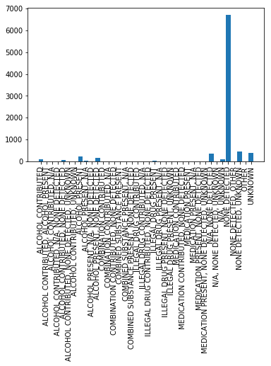

```python
plt.bar(dataByCrashReason2015['Driver Substance Abuse'], dataByCrashReason2015['Count'])
plt.xticks(rotation='vertical')
plt.show()
```

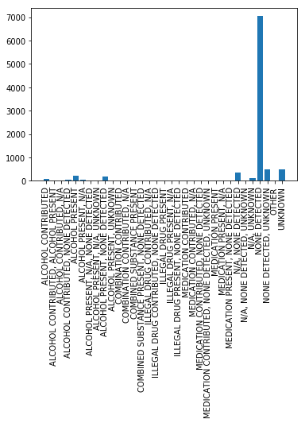

```python
plt.bar(dataByCrashReason2016['Driver Substance Abuse'], dataByCrashReason2016['Count'])
plt.xticks(rotation='vertical')
plt.show()
```

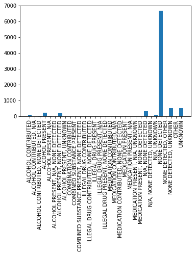

```python
plt.bar(dataByCrashReason2017['Driver Substance Abuse'], dataByCrashReason2017['Count'])
plt.xticks(rotation='vertical')
plt.show()
```

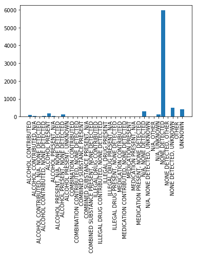

```python
plt.bar(dataByCrashReason2018['Driver Substance Abuse'], dataByCrashReason2018['Count'])
plt.xticks(rotation='vertical')
plt.show()
```

Breaking down the data per year in this manner makes us realize that the vast majority of accidents do not have alcohol involved. While programs and education regarding not drinking and driving are certainly important, relatively speaking there are not that many accidents involving alcohol compared to people just getting into an accident.

# Linear Regression Analysis

Unfortunately we only have 4 years of data to use for a linear regression. This is far from ideal and I would love to have more data before putting a lot of weight on this. Regardless, let's see what comes of it.

## Linear Regression

I used the scikit-learn library to perform this linear regression. If you want to learn more, you can view an example about it at the following link: https://bigdata-madesimple.com/how-to-run-linear-regression-in-python-scikit-learn/

Full documentation can be found here: https://scikit-learn.org/stable/modules/generated/sklearn.linear_model.LinearRegression.html

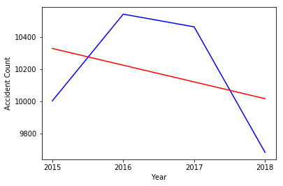

```python
reg = linear_model.LinearRegression()
X = [[x] for x in countsDF['Year'].values]
Y = [[y] for y in countsDF['Accident Count'].values]
regFit = reg.fit(X, Y)

predictedCrashes = []
for x in countsDF['Year'].values:
    predictedCrashes.append(regFit.predict(x)[0][0])

countsDF['Predicted Crashes'] = pd.Series(predictedCrashes, index = countsDF.index)

xi = [2015, 2016, 2017, 2018]
plt.plot(countsDF['Year'], countsDF['Accident Count'], color='blue')
plt.plot(countsDF['Year'], countsDF['Predicted Crashes'], color='red')
plt.xlabel('Year')
plt.ylabel('Accident Count')
plt.xticks(xi, countsDF['Year'])
plt.show()
```

Now I'm going to see how well this model fits the data. To do so I will be using the OLS library from statsmodels.

More information can be found here: https://www.statsmodels.org/dev/examples/notebooks/generated/ols.html

Full documentation can be found here: https://www.statsmodels.org/dev/generated/statsmodels.regression.linear_model.OLS.html

```python
countsDF.columns = ['Year', 'Counts', 'Predicted']
regression = ols(formula='Counts ~ Year', data=countsDF).fit()
regression.summary()
```

OLS Regression Results

| Dep. Variable: | Counts | R-squared: | 0.110 |
| --- | --- | --- | --- |
| Model: | OLS | Adj. R-squared: | -0.334 |
| Method: | Least Squares | F-statistic: | 0.2483 |
| Date: | Sat, 15 Dec 2018 | Prob (F-statistic): | 0.668 |
| Time: | 16:16:30 | Log-Likelihood: | -28.880 |
| No. Observations: | 4 | AIC: | 61.76 |
| Df Residuals: | 2 | BIC: | 60.53 |
| Df Model: | 1 |  |  |
| Covariance Type: | nonrobust |  |  |

|  | coef | std err | t | P>\|t\| | [0.025 | 0.975] |
| --- | --- | --- | --- | --- | --- | --- |
| Intercept | 2.203e+05 | 4.22e+05 | 0.522 | 0.653 | -1.59e+06 | 2.03e+06 |
| Year | -104.2000 | 209.111 | -0.498 | 0.668 | -1003.932 | 795.532 |

| Omnibus: | nan | Durbin-Watson: | 2.001 |
| --- | --- | --- | --- |
| Prob(Omnibus): | nan | Jarque-Bera (JB): | 0.665 |
| Skew: | 0.002 | Prob(JB): | 0.717 |
| Kurtosis: | 1.003 | Cond. No. | 3.64e+06 |

Warnings:  
[1] Standard Errors assume that the covariance matrix of the errors is correctly specified.  
[2] The condition number is large, 3.64e+06. This might indicate that there are  
strong multicollinearity or other numerical problems.

# Conclusion

As mentioned previously, any result from this should be taken with a large grain of salt. I am only able to pass in 4 data points while 8 is the acceptable minimum. While the line is certainly trending downward, it is not necessarilly a valid test since I simply do not have enough yearly data to conduct this.

Based on the current data, we can see that accident counts are dropping but the question of if we will hit our goal outlined in Vision Zero by 2030 is yet to be seen. Until then, we need to focus engineering the roads, educating people, and enforcing the law.

## References

- Dataset: https://data.montgomerycountymd.gov/Public-Safety/Crash-Reporting-Incidents-Data/bhju-22kf
- Pandas:
  - https://pandas.pydata.org/pandas-docs/stable/
  - https://pandas.pydata.org/Pandas_Cheat_Sheet.pdf
  - https://pandas.pydata.org/pandas-docs/stable/generated/pandas.DataFrame.groupby.html
- Matplotlib: https://matplotlib.org/
- scikit-learn
  - https://bigdata-madesimple.com/how-to-run-linear-regression-in-python-scikit-learn/
  - https://scikit-learn.org/stable/modules/generated/sklearn.linear_model.LinearRegression.html
- statsmodels OLS:
  - https://www.statsmodels.org/dev/examples/notebooks/generated/ols.html
  - https://www.statsmodels.org/dev/generated/statsmodels.regression.linear_model.OLS.html